# HW2-ReganAlt-545

Regan Alt

3/22/2021

### Set working directory:

### Question 1: What is the different between doing a census and taking a sample?

##### The difference between conducting a census versus taking a sample is that a census is factual data derived from the entire population of a given area. In this case it is every citizen of the United States in 2010. On the other hand, a sample is just a given portion or subset of the overall population. A sample is meant to be an accurate representation of the larger population, thus analyses based on samples are not perfectly accurate, and are thus more estimations of the variables.

### Question 2:

#### (A) There are 50 states, so why are there more than 50 rows in the data set?

##### Even though there are 50 states in the United States, there are 55 rows of data here because the dataset takes into account Puerto Rico and Washington DC, even though these territories are not officially recognized as states. Additionally, the first 3 rows in the dataset are also counted, even though they contain column names and other values we are not using for this analysis.

```r
 # load file “PEP 2018 PEPANNRES with ann.csv”
population_data <- read_delim("PEP_2018_PEPANNRES/PEP_2018_PEPANNRES_with_ann.csv", col_names=TRUE, delim=",")
# format population data
# delete first row because data does not begin until line 4 (?)
population_data <- population_data[-1,]
#Select and rename the columns
pop2018 <- population_data[c("GEO.display-label", "rescen42010", "respop72018")]
pop2018 <- pop2018 %>% rename(state = "GEO.display-label", res2010="rescen42010", pop2018="respop72018")
pop2018 %>% names()
```

```
## [1] "state"   "res2010" "pop2018"
```

```r
# change the datatype of the columns res2010 and pop2018 to integer
pop2018 <- pop2018 %>% mutate(res2010 = as.numeric(res2010), pop2018 = as.numeric(pop2018))
```

#### (B) What is the resident population of the U.S. according to the 2010 census? Which geographies are included/excluded from this total?

```r
# There is no missing data
pop2018.rectangle <- pop2018 %>% drop_na()
pop2018.rectangle
```

```
## # A tibble: 53 x 3
##    state                  res2010   pop2018
##    <chr>                    <dbl>     <dbl>
##  1 United States        308745538 327167434
##  2 Alabama                4779736   4887871
##  3 Alaska                  710231    737438
##  4 Arizona                6392017   7171646
##  5 Arkansas               2915918   3013825
##  6 California            37253956  39557045
##  7 Colorado               5029196   5695564
##  8 Connecticut            3574097   3572665
##  9 Delaware                897934    967171
## 10 District of Columbia    601723    702455
## # ... with 43 more rows
```

```r
#delete rows for United States, District of Columbia, and Puerto Rico so there are 50 states
pop2018_clean <- pop2018[-c(1, 10, 53),]
pop2018_clean
```

```
## # A tibble: 50 x 3
##    state        res2010  pop2018
##    <chr>          <dbl>    <dbl>
##  1 Alabama      4779736  4887871
##  2 Alaska        710231   737438
##  3 Arizona      6392017  7171646
##  4 Arkansas     2915918  3013825
##  5 California  37253956 39557045
##  6 Colorado     5029196  5695564
##  7 Connecticut  3574097  3572665
##  8 Delaware      897934   967171
##  9 Florida     18801310 21299325
## 10 Georgia      9687653 10519475
## # ... with 40 more rows
```

```r
#Make a vector of the clean population data in 2010
sum_2010 <- pop2018_clean$res2010
sum_2010
```

```
##  [1]  4779736   710231  6392017  2915918 37253956  5029196  3574097   897934
##  [9] 18801310  9687653  1360301  1567582 12830632  6483802  3046355  2853118
## [17]  4339367  4533372  1328361  5773552  6547629  9883640  5303925  2967297
## [25]  5988927   989415  1826341  2700551  1316470  8791894  2059179 19378102
## [33]  9535483   672591 11536504  3751351  3831074 12702379  1052567  4625364
## [41]   814180  6346105 25145561  2763885   625741  8001024  6724540  1852994
## [49]  5686986   563626
```

```r
#use updated pop2018 for remainder of analysis
pop2018 <- pop2018_clean

#SUMMARIZE All Values in 2010 to get total USA population
sum(pop2018$res2010, na.rm = FALSE)
```

```
## [1] 308143815
```

##### The resident population of the United States in 2010 was around 308143815 people. The official 50 federal states in the USA are incuded in this total, while the people residing in the geographies formerly listed under the column ‘State’ such as ‘United States’, ‘District of Columbia’ and ‘Puerto Rico’ are not included in this total.

#### (c) Calculate the percent change of the total resident population between the 2010 census and 2018. How much has the population grown? Once you’ve answered this question, remove the res2010 column from the data set.

```r
#Sum of 2010 population
total2010 <- sum(pop2018$res2010, na.rm = FALSE)
total2010
```

```
## [1] 308143815
```

```r
#Sum of 2018 population
total2018 <- sum(pop2018$pop2018, na.rm = FALSE)
total2018
```

```
## [1] 326464979
```

```r
#Difference between 2018 and 2010 populations
total2018-total2010
```

```
## [1] 18321164
```

```r
#Total percent change from 2010 to 2018 formula
percent_change <- ((total2018-total2010)/total2018)
percent_change
```

```
## [1] 0.05611984
```

##### The percent change in USA population from 2010 to 2018 was about a 5.6% increase. Overall, the population increased by 18,321,164 people.

###### Remove the res2010 column from the data set.

```r
pop2018 <- pop2018[c("state", "pop2018")]
pop2018 %>% names()
```

```
## [1] "state"   "pop2018"
```

### Question 3:

###### Upload the 2010 data file into R. This file has some extra bits, so the arguments ski pand n.max in the read excel() function from the package readxl may be useful. Keep the columns STATE; APPORTIONMENT POPULATION (APRIL 1, 2010); and APPORTIONED REPRESENTATIVES BASED ON 2010 CENSUS. Rename them state; appor2010; and rep2010

```r
# load ApportionmentPopulation2010.xls”
# load tidyverse
require(tidyverse)
library(readxl)
originalpop2010 <-read_excel("PEP_2018_PEPANNRES/ApportionmentPopulation2010.xls", skip = 8, n_max=52)
```

```
## * `` -> ...3
## * `` -> ...5
```

```r
# delete columns and rows that are not needed
pop2010 <- originalpop2010[,c(-3,-5, -6)]
pop2010 <- pop2010[c(-1, -2),]
# rename columns
pop2010 <- pop2010[c("STATE", "(APRIL 1, 2010)", "2010 CENSUS")]
pop2010 <- pop2010 %>% rename(state = "STATE", appor2010 = "(APRIL 1, 2010)", rep2010 = "2010 CENSUS")
pop2010 %>% names()
```

```
## [1] "state"     "appor2010" "rep2010"
```

```r
# change the datatype of the columns appor2010 and rep2010 to integer
pop2010 <- pop2010 %>% mutate(appor2010 = as.numeric(appor2010), rep2010 = as.numeric(rep2010))
```

#### (A) Calculate the following summary statistics for the 2010 census population values and put them into an html: minimum, maximium, mean, median, and standard deviation.

##### Minimum Apportionment Population for 2010 Census equals 568,300 citizens.

```r
min.appor = min(pop2010$appor2010)
```

##### Maximum Apportionment Population for 2010 Census equals 37,341,989 citizens.

```r
max.appor = max(pop2010$appor2010)
```

##### Mean Apportionment Population for 2010 Census equals 6,183,669 citizens per state.

```r
mean.appor = mean(pop2010$appor2010)
```

##### Median Apportionment Population for 2010 Census equals 4,452,284 citizens per state.

```r
median.appor = median(pop2010$appor2010)
```

##### Standard Deviation of Apportionment Population for 2010 Census equals 6,869,559 citizens.

```r
sd.appor = sd(pop2010$appor2010)
```

# Summary Statistics in HTML Table

```r
# put the different stats in a table
stats.summary <- c(min.appor,max.appor,mean.appor,median.appor,sd.appor)
names(stats.summary) <- c("Min.", "Max.", "Mean", "Median", "Std.")
kable(stats.summary)
```

|  | x |
| --- | --- |
| Min. | 568300 |
| Max. | 37341989 |
| Mean | 6183669 |
| Median | 4452284 |
| Std. | 6869559 |

#### (B) Which state has the largest population? Which has the smallest? Where does New York fall into the ranking of population size?

##### The state with the largest population is California.

```r
l <- which.max(pop2010$appor2010)
states <- pop2010$state
states[l]
```

```
## [1] "California"
```

##### The state with the smallest population is Wyoming.

```r
s <- which.min(pop2010$appor2010)
states <- pop2010$state
states[s]
```

```
## [1] "Wyoming"
```

##### New york has 19,421,055 citizens, and is ranked as the third most populous state in the United States, behind California and Texas.

```r
#New York Population:
nyrank1 <- pop2010 %>% filter(state=="New York")
nyrank1
```

```
## # A tibble: 1 x 3
##   state    appor2010 rep2010
##   <chr>        <dbl>   <dbl>
## 1 New York  19421055      27
```

```r
# calculate the rank of each state
pop2010$rank <- 51-rank(pop2010$appor2010)
#calculate where New York falls in total state population ranking
nyrank <- pop2010 %>% filter(state=="New York") %>% select(rank)
nyrank
```

```
## # A tibble: 1 x 1
##    rank
##   <dbl>
## 1     3
```

### Question 4:

###### Create two histograms: (a) 2010 apportionment population and (b) log of the 2010 apportionment population (log always means natural log in statistics). Describe the shape of both distributions.

#### (A) Histogram for 2010 Apportionment Population

```r
# load ggplot library
library(ggplot2)

#create a vector of apportionment population in 2010
apporpop2010 <- pop2010$appor2010
apporpop2010
```

```
##  [1]  4802982   721523  6412700  2926229 37341989  5044930  3581628   900877
##  [9] 18900773  9727566  1366862  1573499 12864380  6501582  3053787  2863813
## [17]  4350606  4553962  1333074  5789929  6559644  9911626  5314879  2978240
## [25]  6011478   994416  1831825  2709432  1321445  8807501  2067273 19421055
## [33]  9565781   675905 11568495  3764882  3848606 12734905  1055247  4645975
## [41]   819761  6375431 25268418  2770765   630337  8037736  6753369  1859815
## [49]  5698230   568300
```

```r
#Plot theme settings
theme.info <- theme(plot.title = element_text(size=10, hjust=0.5),
                    axis.title = element_text(size=8),
                    axis.text = element_text(size=8)
                    )

#To ensure the population data is not in scientific notation
options(scipen=999)
format(summary(apporpop2010), big.mark = ",") # using big.mark to add commas
```

```
##         Min.      1st Qu.       Median         Mean      3rd Qu.         Max.
## "   568,300" " 1,838,822" " 4,452,284" " 6,183,669" " 6,704,938" "37,341,989"
```

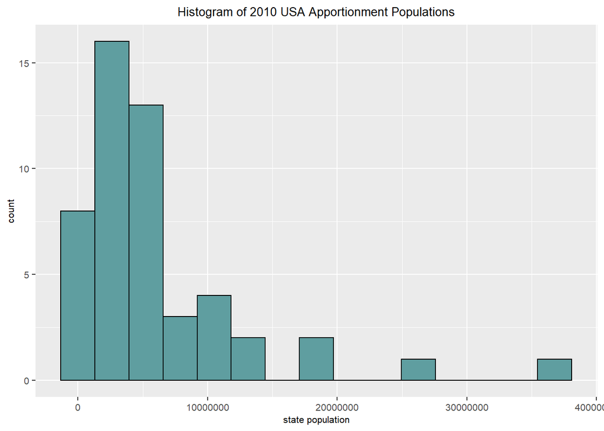

```r
#apporpop histogram:
pop2010 %>%ggplot(aes(apporpop2010)) +
  geom_histogram(bins=15, color="black", fill="cadetblue") +
  ggtitle("Histogram of 2010 USA Apportionment Populations") +
  labs(x="state population")+
  theme.info
```

#### (B) Histogram for Log of 2010 Apportionment Population

```r
#need log of appor2010 population data
apporpop_log <- log(apporpop2010)
apporpop_log
```

```
##  [1] 15.38475 13.48912 15.67379 14.88923 17.43563 15.43389 15.09133 13.71112
##  [9] 16.75471 16.09047 14.12803 14.26881 16.36997 15.68756 14.93189 14.86766
## [17] 15.28583 15.33151 14.10300 15.57163 15.69645 16.10922 15.48602 14.90684
## [25] 15.60918 13.80991 14.42082 14.81225 14.09424 15.99111 14.54174 16.78187
## [33] 16.07370 13.42381 16.26380 15.14123 15.16322 16.35986 13.86929 15.35151
## [41] 13.61677 15.66796 17.04507 14.83463 13.35401 15.89966 15.72555 14.43599
## [49] 15.55567 13.25040
```

[figure not shown]

```r
#log of apporpop histogram
pop2010 %>% ggplot(aes(apporpop_log)) +
  geom_histogram(bins=15, color="black", fill="cadetblue") +
  ggtitle("Histogram of Log of 2010 USA Apportionment Populations") +
  labs(x="state population (millions)")+
  theme.info
```

###### In regards to the shapes of the distributions, the histogram with the original apportionment 2010 population data is very skewed to the right due to the states with the highest populations (>15million citizens) such as California, Texas, New York and Florida who are outliers compared to the rest of the states that are centered around the mean population of about 6 million. Regarding the distribution of the histogram for the log of the 2010 apportionment data, the plot is nearly bell-shaped. Since the data is quite varied and skewed-right, this log histogram portrays a more equally visual representation of population distribution among the 50 states.

### Question 5:

#### Looking at your histograms in Question 4, is the mean or the median a better measure for center in each case? Justify your answer.

```r
# Mean Apportionment Population for 2010 Census equals 6,183,669 citizens per state.
mean(pop2010$appor2010)
```

```
## [1] 6183669
```

```r
#Median of log of 2010 apportionment population data equals 15.30867
median(apporpop_log)
```

```
## [1] 15.30867
```

###### In regards to the “Histogram of the 2010 USA Apportionment Populations”, which is very skewed-right, the mean is a better measure of looking for the center. This is because after creating a histogram based on the whole number population data, the distribution will naturally gravitate around the mean. This is clearly represented in this case, since the majority of the bars are centered around the mean of 6,183,669 people, and the states with more than 15 million are skewed right. On the other hand, the histogram derived from the log of the total apportionment population for each state is better represented by looking at the median for the center. This is clear since the majority of the graph is centered around the median log value for the apportionment population size of 15.30.

### Question 6:

##### Create scatter plots with 2010 apportionment population on the x-axis and number of House members on the y-axis

#### (A) Scatterplot for 2010 apportionment population

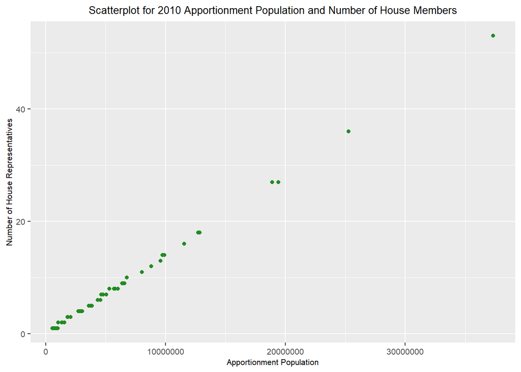

```r
#apporpop2010 = vector for 2010 apportionment population
#rep2010 = number of house members
pop2010 %>% ggplot(aes(x=apporpop2010, y=rep2010)) +
  geom_point(shape=19, color="forestgreen") +
  ggtitle("Scatterplot for 2010 Apportionment Population and Number of House Members") +
  labs(x="Apportionment Population", y="Number of House Representatives") +
  theme.info
```

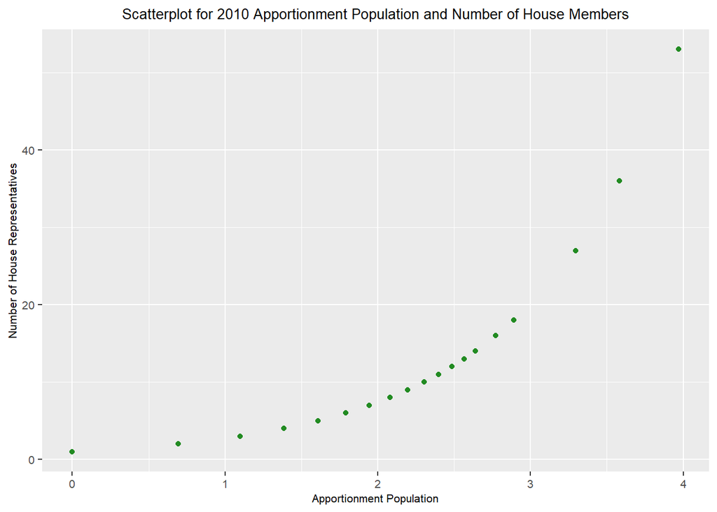

```r
#apporpop_log = vector of log for 2010 apportionment population
#rep2010 = number of house members
pop2010 %>% mutate(apporpop2010 = log(apporpop2010),
                   apporpop2010 = log(rep2010)) %>%
  ggplot(aes(x=apporpop2010, y=rep2010)) +
  geom_point(shape=19, color="forestgreen") +
  ggtitle("Scatterplot for 2010 Apportionment Population and Number of House Members") +
  labs(x="Apportionment Population", y="Number of House Representatives") +
  theme.info
```

### Question 7.

##### Merge the 2018 population data and the 2010 apportionment data into a single R object called data.x.

```r
#find common variable on which to merge the data
#the common variable of the data sets already in R is the column "state"
#csv file  -> pop2018 / excel file -> pop2010
#to see the differences between the data sets
setdiff(pop2018$state, pop2010$state)
```

```
## character(0)
```

```r
setdiff(pop2010$state, pop2018$state)
```

```
## character(0)
```

```r
#there is no missing or different data in either dataset

##the common variable of the data sets already in R is the column "state"
# Using left_join(x,y) to use "state" to match the two tibbles
# x axis = pop2010, y axis = pop2018
# joining the data on the "state" column
data.x <- pop2018 %>% left_join(pop2010 %>% select(state, appor2010), by="state")
```

#### Estimate what the number of House members for each state would be in 2020 based on your 2018 population data using the equal proportions method.

```r
# Using the equal proportions method - Estimated number of House members for each state
# Step 1) Calculate a vector of values of the formula 1/sqrt(n(n − 1)) where n goes from 2 to 60 and call it denom.
denom <- 1/sqrt(c(2:60)*c(1:59))
# Step 2) Multiply each value of denom in Step 1 by each state’s 2018 population.
pvals <- t(outer(data.x$pop2018, denom))
colnames(pvals) <- data.x$state
rownames(pvals) <- c(2:60)
# Step 3) Create a data set with the priority values as one column and the corresponding state names as a second column.
priority.values <- as.data.frame(as.table(pvals))
colnames(priority.values) <- c("n", "state", "pval")
# Step 4) Sort your data set in Step 3 in descending order by priority value so that the highest priority values are on top.
r385 <- priority.values %>% top_n(385)
# Step 5) frequency table of initial number of representatives per state
freq <- r385 %>% count(state)
freq
```

```
##             state  n
## 1         Alabama  6
## 2         Arizona  9
## 3        Arkansas  3
## 4      California 52
## 5        Colorado  7
## 6     Connecticut  4
## 7         Florida 27
## 8         Georgia 13
## 9          Hawaii  1
## 10          Idaho  1
## 11       Illinois 16
## 12        Indiana  8
## 13           Iowa  3
## 14         Kansas  3
```

[output cut: 28 more lines]

```r
# Step 6) & 7) Merge your frequency table with data.x. Then, replace all NA counts with 0 using the function replace na(). Add 1 to each state representative count so that each state has at least one representative and the total number of representatives equals 435.
data.x <- data.x %>% left_join(freq, by="state") %>% mutate(n = replace_na(n, 0) + 1)
# add newly estimated representatives back to the original data
data.x <- data.x %>% left_join(pop2010 %>% select(state, rep2010), by = "state")
```

#### A) Make an html table with the three states that currently have the highest number of representatives

```r
# the three highest representatives, based on the new calculation
highest3 <- data.x %>% top_n(3, n)
highest3$state
```

```
## [1] "California" "Florida"    "Texas"
```

```r
# calculate the current percentage
sum(highest3$n) / sum(data.x$n) # about 27%
```

```
## [1] 0.2735632
```

```r
# for the current representatives:
highest3.current <- data.x %>% top_n(3, rep2010)
highest3.current$state
```

```
## [1] "California" "Florida"    "New York"   "Texas"
```

```r
#New York is included because it has the same amount of Representatives as Florida

# n = estimated number of 2020 representatives per state
library(knitr)
kable(highest3)
```

| state | pop2018 | appor2010 | n | rep2010 |
| --- | --- | --- | --- | --- |
| California | 39557045 | 37341989 | 53 | 53 |
| Florida | 21299325 | 18900773 | 28 | 27 |
| Texas | 28701845 | 25268418 | 38 | 36 |

##### What fraction of the total number of representatives do these 3 states comprise?

###### These states (California, Florida and Texas) comprise nearly 27 percent of the total number of representatives in Congress.

##### Currently, do the same states have the highest number of representatives?

###### Yes, currently the same states (California, Texas, Florida) do have the highest number of representatives. The only difference is that based on the 2010 census, Florida and New York had the same amount of representatives, creating technically 4 states who had the top representation in Congress. Based on our estimates from the 2020 data, however, California, Texas and Florida remain as having the top three states with the highest amount of representation, while New York has decreased by one.

#### B) How many states currently have only a single House of Representatives member?

```r
onerep <- data.x %>% filter(rep2010 == 1) # all of these still get only one representative with out estimate
dim(onerep)[1]
```

```
## [1] 7
```

##### Currently, 7 states have only a single House of Representatives member.

### Question 8:

##### Calculate the following difference: (estimated 2020 house reps − 2010 house reps) as a new column in data.x and convert it to a character data type. Call this column difference. Make an html frequency table of the differences column.

```r
data.x <- data.x %>% mutate(diff = as.character(n - rep2010))
# make table of the difference between Estimated 2020 House Reps and 2010 House Reps
# Column named "n" represents number of states
kable(data.x %>% count(diff))
```

| diff | n |
| --- | --- |
| -1 | 7 |
| 0 | 37 |
| 1 | 5 |
| 2 | 1 |

### Question 9:

```r
require(tidyverse)
require(gridExtra)
require(usmap)
```

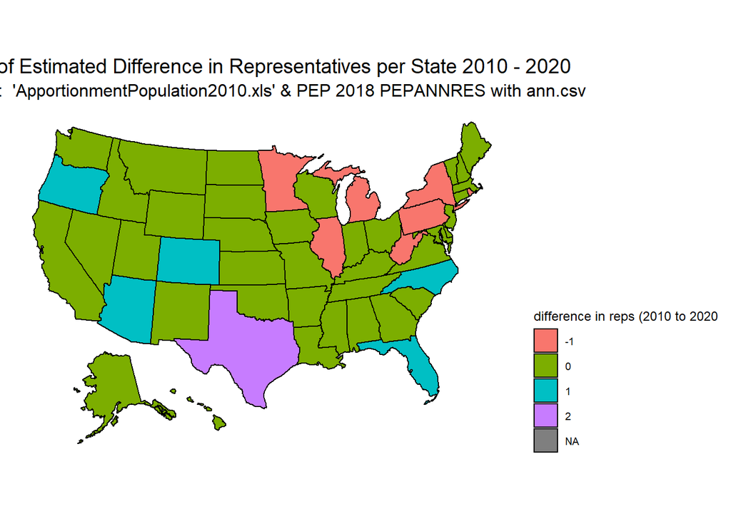

```r
require(ggplot2)
# plot_usmap(pop2010, values="rep2010", regions = "states") +  labs(title = "U.S. States", subtitle = "This is a blank map of the United States.") + theme(panel.background=element_blank())
# convert state names to fips code
# rownames(pop2010) <- fips(pop2010$state)
# data.x <- %>% mutate(fips=substr(fips, start=2, stop=3))

### to plot data on map
plot_usmap(regions="states", data=data.x,
           values = "diff") +
  #for a gradient color
  #scale_fill_gradient(name = "number of reps/state",
  #                    low = "#56B1F7", high = "#132B43") +
  ggtitle("Map of Estimated Difference in Representatives per State 2010 - 2020") +
  # for the aesthetic color-coding information
  labs(fill="difference in reps (2010 to 2020",
       subtitle="(Source:  'ApportionmentPopulation2010.xls' & PEP 2018 PEPANNRES with ann.csv") +
  theme(legend.position = "right",
        plot.title = element_text(size=14, hjust =0.5),
        plot.subtitle = element_text(size=12, hjust=0.5))
```

#### (D) Describe one way we could improve our analysis.

##### One way we could improve our analysis is by incorporating data based on political, economic, or other major events such as a global pandemic that have inspired people to move around the United States. This would give more depth to the analysis, and provide an explanation for why some states have lost or gained representation in Congress over others.